# オープンサイエンスの実践方法

専修大学 国里愛彦

2026-11-06

## 国里愛彦（くにさと よしひこ）

専修大学人間科学部心理学科 教授

専門：計算論的精神医学，認知行動療法

COI開示：国里の著書や関連する団体について紹介するが，特定企業との利益相反はない。

## 本日の内容

1. 再現性の問題
2. オープンデータ
3. オープンマテリアル
4. 事前登録
5. OSFの変更

# 再現性の問題

## 再現性の危機

- 心理学研究100本の追試では，元研究では統計的に有意な結果の割合が97%だったが，追試では36%になった(Open Science Collaboration, 2015)。
- 1,576名の研究者への調査では，70%以上が他者の研究，半数以上が自身の研究を再現できなかった経験を報告した(Baker, 2016)。

→ 科学研究全般において再現性の危機が生じている

## ３つの再現性

S. N. Goodman et al. (2016) による区分

1. **方法の再現可能性**：同じデータに同じ方法を用いて，同じ結果が得られる。
2. **結果の再現可能性**：新しいデータに同じ方法を用いて，整合する結果が得られる。
3. **推論の再現可能性**：結果から質的に同じ結論が得られる。

→オープンサイエンスが必要

## データとコードが入手できない

- 「同じデータに同じ方法を用いる」には，データと解析方法が必要。
- 2015〜2017年の生物医学論文の調査では，データの入手可能性の記載は18.3%(Wallach et al., 2018)。
- 2014〜2017年の心理学論文の調査では，生データ共有は2%，解析コード共有は1%(Hardwicke et al., 2022)。

## 公開だけでは再現できない

- 「同じデータ + 同じ方法 = 同じ結果」って，当たり前じゃないの？
- Science誌の204論文の調査では，必要な資料を入手できたのは全体の44%，結果を再現できたのは全体の26%(Stodden et al., 2018)。
- 社会・行動科学の100件の研究について，5名が独立に再解析した結果，再解析者**全員**が元研究と同じ結論に達した研究は34%(Aczel et al., 2026)。

→データもコードもあっても再現できない・・・

# オープンデータ

## 方法の再現可能性を高める(データ)

- 第三者が利用できる形式で，データと説明資料を共有する。
- ヒトのデータでは，同意・倫理審査・再識別のリスクを踏まえて共有範囲を決める。
- 解析コードは，実行順序や処理の意味が第三者に伝わるように書く。

→ オープンデータとコード公開によって，再現性の検討だけでなく，二次分析研究も可能になり，次の研究にも活かせる (Levenstein & Lyle, 2018)。

## オープンデータを作る5ステップ

1. **計画と同意**：共有範囲を研究開始前に決める。
2. **プライバシー保護**：公開可能なデータセットを用意する。
3. **データの整理**：READMEとコードブックを添える。
4. **ライセンス**：再利用の条件を明示する。
5. **リポジトリ**：確定版を公開し，論文と結び付ける。

※ A. Goodman et al. (2014) の10のルールと Levenstein & Lyle (2018) の4ステップを基に，国里がまとめたもの

## 1. 計画と同意

- データ収集前に，「誰に・何を・何のために共有するか」を決め，データ共有についてインフォームドコンセントをとる。
- 保管場所・保存期間，二次利用の範囲，利用申請の方法を明示する。
- 公開後の同意撤回や削除に対応できる範囲も説明する。
- 既存データの利用は，元の研究での説明・同意と倫理審査の条件を確認する (Meyer, 2018; 日本学術振興会, 2021)。

## 2. 公開用データのプライバシー保護

- 氏名・連絡先などの直接識別子を除く。
- 年齢・地域・日付・稀な属性の**組合せ**による特定も検討する。
- 値の削除（抑制）や，年齢を年代にする処理（一般化）を使い，変更内容を記録する。
- 自由記述・音声・映像は，数値データとは別に検討が必要 (Walsh et al., 2018)。

## 3. 再利用できるデータとFAIR

| FAIR原則 | 具体的な準備 |
| --- | --- |
| **Findable** (見つけられる) | DOI，タイトル，キーワード，メタデータ |
| **Accessible** (アクセスできる) | 取得方法や，必要な認証・申請の手順 |
| **Interoperable** (相互運用できる) | 分野の標準形式・語彙，機械が読めるデータ |
| **Reusable** (再利用できる) | 変数の説明，データの来歴，利用条件 |

## 整然データの例

- 複数時点で測定したデータは，時点ごとに列を分けるWide形式が人間は確認しやすい
- 一方，Rでの可視化や解析には，測定時点と測定値を別々の列に整理するLong形式(整然データ)が便利(Wickham, 2014)。

| participant_id | time | condition | score |
| --- | --- | --- | --- |
| P001 | pre | intervention | 12 |
| P001 | post | intervention | 8 |
| P002 | pre | control | 10 |
| P002 | post | control | 11 |

## READMEとコードブック

- **README**：研究の概要，ファイルの役割，引用方法，連絡先など
- **コードブック**：各変数の意味と読み方（尺度の出典，単位，逆転項目，得点化，除外・変更履歴など） (Arslan, 2019)。

| 例）変数 | 説明 | 値・欠測の扱い |
| --- | --- | --- |
| participant_id | 公開用参加者ID | 個人との対応表は含めない |
| time | 測定時点 | pre＝介入前，post＝介入後 |
| condition | 割り付けた群 | intervention＝介入群，control＝対照群 |
| score | 架空の症状尺度の合計点 | 0〜21点，高いほど症状が強い，NA＝欠測 |

## 4. ライセンスと利用条件

| 対象 | 選択肢の例 |
| --- | --- |
| データ | CC0，またはCC BY 4.0 |
| 自作の説明文・マテリアル | CC BY 4.0など |
| ソフトウェア・解析コード | MIT，Apache 2.0，GPLなど |

- CC BYでは，出典・ライセンス・変更の有無を示す (Creative Commons, 2026)。
- 第三者の尺度・画像・コードは，元の利用条件を確認した上で共有する。

## 5. 確定版の保存と公開

1. データ・説明資料・コードを揃え，第三者の立場で確認する。
2. 適切なリポジトリに，著者・概要・利用条件を登録する。
3. DOIとバージョンを確認し，論文・事前登録とのリンクを付ける。
4. 論文に，データの保存先と入手方法を記載する。

※データを共有するリポジトリについては後述

# オープンマテリアル

## 方法の再現可能性を高める(解析)

- 生データ(少なくとも公開データ)から最終的な結果までが追跡できるようにコードとドキュメントを用意する(手動の作業を減らす)。

[figure not shown]

## ファイルやフォルダの構造化

- 第三者が追跡できるように，実行するコードの順番や説明を入れたり，データがどこにあるか分かりやすいように配置する。

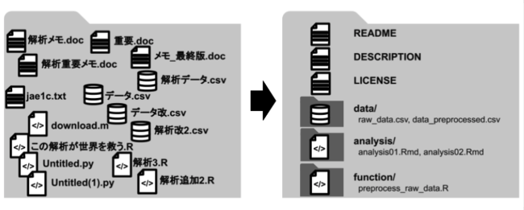

## Research Compendium

- データ・コード・文書を，研究単位でまとめて配布する(Marwick et al., 2018)。
- データと解析結果を分け，実行順序と必要な環境をREADMEに記す。
- 繰り返し使う関数をパッケージとして整理する方法もある。

```
README.md       研究概要・実行手順
data/           公開可能なデータとコードブック
analysis/       前処理・解析のスクリプト
output/         コードから生成する図表
manuscript.qmd  本文と解析結果
```

## 計算モデルのパッケージ化

心理学の理論を表す計算モデルを，他の研究でも使えるツールとして配布する提案 (Evers et al., 2026)。

- 利用しやすくする：R・Python・Juliaなどのパッケージに，機能ごとに分けた関数，説明文書，実行例，ライセンスをつける
- 検証と保存：テストと更新時の自動検査を行い，変更履歴を管理し，各リリースをDOI付きで保存する。
- 実行環境も別途共有：パッケージ化だけでは，依存ソフトのバージョンやOSは固定されない。

## 解析環境の再現性

- 解析環境が違うと結果が再現できないことがあるので，解析環境やバージョン情報も公開
- Pythonならuv，Rならrenvでバージョン管理，Dockerを使ってOSやソフトを含んだコンテナを共有

[figure not shown]

## 結果の再現可能性を低める要因

- 追試をする場合に必要な情報が足りないことが多い。心理・社会的介入の臨床試験では，必要な内容がちゃんと記載されている論文は半分以下とも(Grant et al., 2013)。
- 心理学で用いる認知課題がそのまま提供されることは少なく，論文の少ない情報から読み解いたり，著者に確認が必要なことも

→方法が微妙に違うので再現できない？

## 結果の再現可能性を高める

- 臨床研究においては，研究報告ガイドラインが整備されてきており，この遵守は，結果の再現可能性を高めることが期待できる。
- 研究実施にかかわるマテリアルをそのまま公開することも増えている。
- 心理学や精神医学での実験は，実験室への入室時の対応のようなことでも結果が左右される可能性がある。言語化しにくい情報をビデオなどで共有したりする必要もあるかもしれない（国際的な大規模追試プロジェクトでは行われている）。

## 共有するマテリアル

- 実際に参加者に提示したマテリアルを共有（バージョン・動作環境・利用条件も）(Gilmore et al., 2018)。
- 配布時の既存のマテリアルの権利関係には配慮

| 対象 | 含める情報の例 |
| --- | --- |
| 質問紙 | 項目・選択肢・提示順，得点化 |
| 認知課題 | 刺激，教示，時間設定，コード |
| 調査・介入の手順 | 実施マニュアル，担当者の対応，変更履歴 |

## CBAT

[Cognitive & Behavioral Assessment Toolbox(CBAT)](https://cbat.cpsy-lab.com/)

- jsPsychやlab.jsで作った，認知課題・質問紙のスクリプトを共有するプラットフォーム(Toyama et al., 2026)
- デモで動作を確認し，GitHubのコードを研究に活用できる。
- 現状では権利関係で質問紙が少なく，タスクもまだ十分ではない。

# 事前登録

## 推論の再現可能性

- 推論の再現可能性は、結果から質的に同じ結論が得られること。
- 推論の再現可能性は担保が非常に難しい。結果の解釈、前提の知識や条件が著者や読者で異なることも多い。

→ どのように解釈したかを，第三者が追跡できることが大切。

## *p*-hacking

- 有意な結果を得るために，収集・分析・報告を選び直すこと。
- 例：結果を見ながら，有意になるまでデータを追加する(N増し)
- 例：複数のアウトカムや共変量の組合せから，有意な分析だけを報告する（選択的アウトカム報告）

→*p*hackingをしてしまうと偽陽性率が想定より高くなってしまう

## HARKing

- Hypothesizing After the Results are Known(Kerr, 1998)
- 結果を見た後に立てた仮説を，事前に立てた仮説として報告すること。
- 読者が「新しいデータで予測が的中した」と受け取り，証拠の強さを過大評価する可能性がある。

→結果から仮説を考えることは有用だが、時間を遡らない

## 研究者自由度と事前登録

- 同じ問いにも複数の妥当な研究・分析方法がある (平石 & 中村, 2022)

| 選択 | 選択肢の例 |
| --- | --- |
| 測定する指標 | どの尺度・項目・測定時点を使うか |
| 分析対象と前処理 | 誰を除くか，欠測や外れ値の扱い |
| 分析モデル | どの共変量・統計モデルを使うか |

- 事前登録によって研究者の自由度に制限をかける

## 事前登録の目的

- 事前登録：結果を見る前に，仮説・方法・解析計画を日時付きで確定する。
- 登録と論文を照合すると，何を先に決め，何を結果の後に決めたかを査読者・読者が確かめられる。
- 計画した検証と，データを見て思い付いた探索を区別し，証拠の強さを判断しやすくする (水野, 2024; 長谷川 et al., 2021)。

## 事前登録に書くこと

| 項目 | 内容 |
| --- | --- |
| 仮説とデザイン | 比較対象，条件，主要アウトカム，測定時点 |
| 対象者・標本数 | 募集条件，目標人数の根拠，募集を止める条件 |
| 除外・前処理 | 参加者・試行の除外基準，欠測・外れ値の扱い |
| 主解析 | モデル，変数，共変量，多重比較 |
| データの状況 | 未収集か，既存データか |

## 登録前に分析を具体化する

- 仮説ごとに，測定指標・モデル・判断基準を対応させる。
- 得点化や変数変換，除外・欠測処理も，第三者が実行できる程度に書く。
- 仮定を満たさない場合などの分岐は，条件と代替方法を先に決める。
- 可能なら解析コードを添え，他者に読んでもらい，曖昧な判断を減らす (水野, 2024; 長谷川 et al., 2021)。

## 事前登録の具体例

架空例：介入群と対照群の介入後の症状得点を比較

| 曖昧な記述 | 判断を追跡できる記述 |
| --- | --- |
| 症状が改善する | 介入4週後の尺度合計点は，対照群より介入群で低い |
| 100名くらい集める | 例数設計で100名と設定。100名の割付完了で募集終了 |
| 群間差を検定する | 介入後得点を目的変数，群と介入前得点を説明変数とする回帰モデル |
| 通常の基準で判断する | 群（介入1・対照0）の係数が負で，両側 p < .05。効果量・95%信頼区間も報告 |

## サンプルサイズと停止規則

- 検出したい効果の大きさ，有意水準・検出力などから，必要人数と根拠を示す（サンプルサイズ設計）。
- 資金・時間の制約で人数を決める場合は，その理由と，検出できる効果の範囲を示す。
- 脱落を見込む場合は，目標人数と募集上限を区別
- 人数・期限など，収集を止める条件を先に決める (水野, 2024; 長谷川 et al., 2021)

※ベイズ統計の場合は、BFを用いた逐次ベイズによる停止ルールも使える

## 計画の変更と研究報告

- 事前登録した主解析は，有意な結果も有意でない結果も報告する。
- 計画を変えた場合は，変更点・理由・時点を記録する。
- 結果を見る前の変更と，結果を見た後の変更を区別する。
- 追加の探索的分析は，登録済みの分析と分けて報告する (水野, 2024)。

## 事前登録と事前審査付き報告

|  | 事前登録 | 事前審査付き報告 |
| --- | --- | --- |
| 研究計画 | 結果を知る前に登録、計画の査読なし | 仮説・方法・解析を第1段階で査読し，原則的採択後に研究を実施 |
| 論文の採択 | 登録だけでは採択は決まらない | 第1段階査読採択＆計画に沿った実施をすると、有意性に関わらず採択 |

## 事前登録は万能ではない

- 登録を複数作り，都合のよいものだけを示すなど，登録後にも選択的な報告は起こりうる。
- 登録しても，測定・研究デザイン・分析方法の妥当性が自動的に高まるわけではない。
- 1つの計画で得た結果が，別の対象・刺激・状況にも当てはまるとは限らない (平石 & 中村, 2022)。

→感度分析や妥当と考える前処理や分析の組合せを系統的に比較するマルチバース分析などで頑健性を検討する。

# OSFの変更

## Open Science Framework(OSF)

- 研究の事前登録，プレプリント公開，データとコードの共有で用いられてきたが、今後はProjectsの機能を段階的に縮小予定

[figure not shown]

## OSF Projectsの機能縮小

- **2026年11月16日から**：新規プロジェクトと子コンポーネントを作成できなくなる (Center for Open Science, 2026a)。
- **2027年2月19日から**：既存の公開・非公開プロジェクトが読み取り専用になる。
- 既存プロジェクトへのファイル追加・編集は，読み取り専用化まで可能。

## 継続する機能

- 事前登録とプレプリントは継続する (Center for Open Science, 2026a)。
- 事前登録はProjectsからではなく，Registriesから直接作成する。
- 完了済みの公開プロジェクトは，URL・DOIとともに維持される。非公開プロジェクトも当面は閲覧可能だが，将来削除する見込み（削除日は未定）

→ これから行う研究はデータ・マテリアル管理・公開にOSF以外のプラットフォームを使う必要がある。

## PsyArXivの新基盤への移行

- 心理学のプレプリントサーバーPsyArXivは，OSFからKnowledge Futuresの新基盤へ移行する (SIPS, 2026)。
- **2026年11月下旬に切替，12月上旬に移行完了予定**（移行中は一時的に審査に遅れが生じるかも）。
- 運営方針・投稿審査は引き続きSIPSが担い，PubPubなどのインフラ構築を担うKnowledge Futuresが技術基盤を提供する。
- **既存URLは新サイトへ自動転送**され，利用者による移行作業は不要(新規投稿には**ORCID iDが必須**)

## 機能縮小の背景

- OSFの機能維持に年400万〜500万ドルが必要だが (Nosek, 2026)，助成金への依存と資金調達の不確実性が継続運営を難しくしている。
- 多機能化に伴う保守，非公開ストレージの維持，スパム対策の負担も増えた。

## 研究公開基盤への不正利用

- OSFが海賊版コンテンツやフィッシングサイトへの誘導に悪用(Ikeda et al., 2026)
- 指導教員の名前で検索すると同名俳優の海賊版リンクに到達し発覚

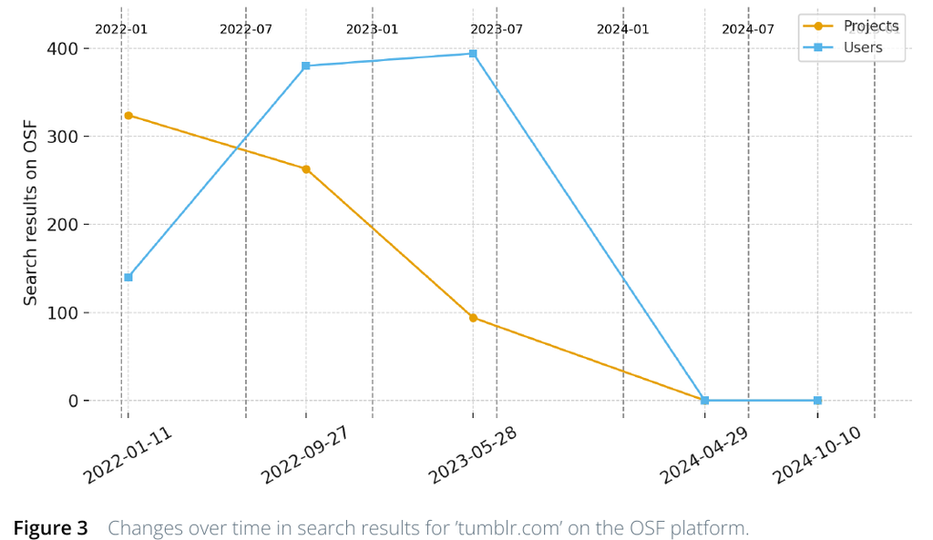

「tumblr.com」の検索結果件数

- 不正なリンクで使用されているtumblr.comで検索すると，OSFが不正なリンクを削除して対応していることが推測される

## OSFのセキュリティ事案

10月24日に不正アクセスを記録し，27日に発見・修正(Center for Open Science, 2026b)。影響人数は不明だが，対応済みであり，利用者の対応は不要

|  | アクセスされた情報・影響の範囲 |
| --- | --- |
| **アクセスされた情報** | 氏名・ユーザーID・メールアドレス。公開・非公開のプロジェクト，事前登録，プレプリントのGUID・タイトル・説明 |
| **ファイル・パスワード等** | 非公開を含むファイルの閲覧・ダウンロード，パスワードへのアクセスはなし。内容の改変・削除・データ消失もなし |

## 用途別のOSFからの移行先

所属機関・研究分野が推奨するリポジトリを確認するのが良いが，以下は用途に応じた候補案

| 研究で行いたいこと | 推奨する組合せ・候補 |
| --- | --- |
| 公開可能なデータ・マテリアルの保存 | 分野・機関リポジトリ，Zenodo／Dataverse |
| 研究ごとにデータ・コード・資料を整理して公開 | ResearchBox，心理学の成果物ならPsychArchivesも候補 |
| コードの共同開発と論文対応版の保存 | GitHubで開発＋Zenodoで確定版にDOI |
| 非公開の共同作業・個人データの管理 | 機関の承認したストレージ／GakuNin RDM |
| 研究計画の事前登録 | OSF Registriesを継続，またはAsPredicted／PreReg＋PsychArchives |

## データなどの保存先を選ぶ基準

Lakens (2026) の比較軸を基に整理する。

| 比較軸 | 確認すること |
| --- | --- |
| 長期存続 | 運営組織，財源，バックアップ・保全の方針 |
| API | R／Pythonから，ファイル・メタデータの取得や検索ができるか |
| メタデータ | 変数の説明や，論文・登録との関連を機械も読み取れるか |
| 匿名査読 | 著者情報を隠して，査読者へ共有できるか |
| 使いやすさ | 投稿者と，再利用する人の双方が使いやすいか |
| 個人データの扱い | 共有範囲，アクセス制御，必要な契約が合うか |

## Zenodo

- 分野・機関の適切な保存先がない場合の有力候補。CERNがホストする汎用リポジトリ。
- 公開時にDOIを付与。標準容量は1レコード50GB (CERN, 2026)。
- データにREADME・コードブックを添え，刺激・質問紙・実施手順・解析コードも整理する。
- 更新時は版を管理し，論文で使用した版を引用する。公開レコードのメタデータは誰でも閲覧できる。

## ResearchBox

- データ・コード・マテリアル・事前登録を，研究ごとの表に整理して共有する。
- APIを公開。R／Pythonからファイル・メタデータを取得し，公開データやコードを検索できる (ResearchBox, 2026)。
- 変数の名前・説明や，コードの中身からも再利用する資料を探せる。
- 公開Boxは，ZenodoとInternet Archiveにもバックアップされる。

## 非公開の共同作業と個人データ

- 作業中の非公開資料は，機関の承認したストレージやGakuNin RDMで管理する (国立情報学研究所, 2026)。
- 公開用のデータ・マテリアルを別に準備し，利用条件に合う公開先へ登録する。
- 参加者IDとの対応が残るデータなどは，氏名の削除だけで公開可能と判断しない。
- 非公開設定やアクセス制限がある場合も，研究で認められた共有範囲と保存条件を確認する。

## 日本での再現可能性への取り組み

- [JCORS](https://osf.io/z4cgu/)：透明性の高い研究のための情報共有。
- [ReproducibiliTea](https://reproducibilitea.org/)：再現可能性を学ぶ抄読会。
- 『心理学評論』の特集：「心理学の再現可能性」（59巻1号），「統計革命」（61巻1号），「心理学研究の新しいかたち」（62巻3号）。

## 最後に宣伝

[figure not shown]

- [国里愛彦・清水裕士・武藤拓之(2026).『これからの心理学研究法』有斐閣](https://link.amazon/B0hDKh4GH)
- 国里愛彦(2027)『RStudioとQuartoによる再現可能な論文執筆（仮）』金芳堂

## 引用文献

Aczel, B., Szaszi, B., Clelland, H. T., Kovacs, M., Holzmeister, F., Ravenzwaaij, D. van, Schulz-Kümpel, H., Hoffmann, S., Nilsonne, G., Kosa, L., Torma, Z. A., Abdelfatah, Y., Aberson, C. L., Acar, O. A., Acem, E., Adamkovic, M., Adamovich, T., Adiasto, K., Ahnström, L., … Nosek, B. A. (2026). Investigating the analytical robustness of the social and behavioural sciences. *Nature*, *652*(8108), 135–142. https://doi.org/10.1038/s41586-025-09844-9

Arslan, R. C. (2019). How to automatically document data with the codebook package to facilitate data reuse. *Advances in Methods and Practices in Psychological Science*, *2*(2), 169–187. https://doi.org/10.1177/2515245919838783

Baker, M. (2016). 1,500 scientists lift the lid on reproducibility. *Nature*, *533*(7604), 452–454. https://doi.org/10.1038/533452a

Center for Open Science. (2026a). *OSF changes*. https://www.cos.io/osf-changes

Center for Open Science. (2026b). *Notice of OSF security incident, october 2026*. 利用者向け電子メール.

CERN. (2026). *Manage storage quota*. https://help.zenodo.org/docs/deposit/manage-quota/

Creative Commons. (2026). *Attribution 4.0 international (CC BY 4.0)*. https://creativecommons.org/licenses/by/4.0/

Evers, K. C., Waldorp, L., Fried, E. I., Hasselman, F., & Borsboom, D. (2026). *Packaging psychological theory: A new standard for reusable computational models* [Unpublished manuscript].

Gilmore, R. O., Kennedy, J. L., & Adolph, K. E. (2018). Practical solutions for sharing data and materials from psychological research. *Advances in Methods and Practices in Psychological Science*, *1*(1), 121–130. https://doi.org/10.1177/2515245917746500

Goodman, A., Pepe, A., Blocker, A. W., Borgman, C. L., Cranmer, K., Crosas, M., Di Stefano, R., Gil, Y., Groth, P., Hedstrom, M., Hogg, D. W., Kashyap, V., Mahabal, A., Siemiginowska, A., & Slavkovic, A. (2014). Ten simple rules for the care and feeding of scientific data. *PLoS Computational Biology*, *10*(4), e1003542. https://doi.org/10.1371/journal.pcbi.1003542

Goodman, S. N., Fanelli, D., & Ioannidis, J. P. A. (2016). What does research reproducibility mean? *Science Translational Medicine*, *8*(341), 341ps12. https://doi.org/10.1126/scitranslmed.aaf5027

Grant, S. P., Mayo-Wilson, E., Melendez-Torres, G. J., & Montgomery, P. (2013). Reporting quality of social and psychological intervention trials: A systematic review of reporting guidelines and trial publications. *PLoS ONE*, *8*(5), e65442. https://doi.org/10.1371/journal.pone.0065442

Hardwicke, T. E., Thibault, R. T., Kosie, J. E., Wallach, J. D., Kidwell, M. C., & Ioannidis, J. P. A. (2022). Estimating the prevalence of transparency and reproducibility-related research practices in psychology (2014–2017). *Perspectives on Psychological Science*, *17*(1), 239–251. https://doi.org/10.1177/1745691620979806

Ikeda, A., Yonemitsu, F., Yoshimura, N., Sasaki, K., & Yamada, Y. (2026). The open science platforms fighting clandestine abuses of piracy and phishing: Case of open science framework. *Journal of Trial & Error*. https://doi.org/10.36850/57fe-4c10

Kerr, N. L. (1998). HARKing: Hypothesizing after the results are known. *Personality and Social Psychology Review*, *2*(3), 196–217. https://doi.org/10.1207/s15327957pspr0203_4

Lakens, D. (2026). *Which data repository should you use?* The 20. https://daniellakens.blogspot.com/2026/08/which-data-repository-should-you-use.html

Levenstein, M. C., & Lyle, J. A. (2018). Data: Sharing is caring. *Advances in Methods and Practices in Psychological Science*, *1*(1), 95–103. https://doi.org/10.1177/2515245918758319

Marwick, B., Boettiger, C., & Mullen, L. (2018). Packaging data analytical work reproducibly using R (and friends). *The American Statistician*, *72*(1), 80–88. https://doi.org/10.1080/00031305.2017.1375986

Meyer, M. N. (2018). Practical tips for ethical data sharing. *Advances in Methods and Practices in Psychological Science*, *1*(1), 131–144. https://doi.org/10.1177/2515245917747656

Nosek, B. (2026). *OSF changes: A note to users*. https://www.cos.io/blog/osf-changes-a-note-to-users

Open Science Collaboration. (2015). PSYCHOLOGY. Estimating the reproducibility of psychological science. *Science (New York, N.Y.)*, *349*(6251), aac4716. https://doi.org/10.1126/science.aac4716

ResearchBox. (2026). *ResearchBox API v1.0*. https://researchbox.org/api

SIPS. (2026, November 2). *PsyArXiv is moving to a new platform!* PsyArXiv Blog. https://blog.psyarxiv.com/2026/11/02/psyarxiv-is-moving-to-a-new-platform/

Stodden, V., Seiler, J., & Ma, Z. (2018). An empirical analysis of journal policy effectiveness for computational reproducibility. *Proceedings of the National Academy of Sciences of the United States of America*, *115*(11), 2584–2589. https://doi.org/10.1073/pnas.1708290115

Toyama, A., Kunisato, Y., Yamashita, Y., & Suzuki, S. (2026). Cognitive & behavioral assessment toolbox ( CBAT ): An open‐source platform supporting experiments in computational psychiatry. *Psychiatry and Clinical Neurosciences*, *80*(6), 469–476. https://doi.org/10.1111/pcn.70045

Wallach, J. D., Boyack, K. W., & Ioannidis, J. P. A. (2018). Reproducible research practices, transparency, and open access data in the biomedical literature, 2015-2017. *PLoS Biology*, *16*(11), e2006930. https://doi.org/10.1371/journal.pbio.2006930

Walsh, C. G., Xia, W., Li, M., Denny, J. C., Harris, P. A., & Malin, B. A. (2018). Enabling open-science initiatives in clinical psychology and psychiatry without sacrificing patients’ privacy: Current practices and future challenges. *Advances in Methods and Practices in Psychological Science*, *1*(1), 104–114. https://doi.org/10.1177/2515245917749652

Wickham, H. (2014). Tidy data. *Journal of Statistical Software*, *59*(10), 1–23. https://doi.org/10.18637/jss.v059.i10

国立情報学研究所. (2026). *GakuNin RDMについて*. https://support.rdm.nii.ac.jp/about/

平石界., & 中村大輝. (2022). 心理学における再現性危機の10年：危機は克服されたのか，克服され得るのか. *科学哲学*, *54*(2), 27–50. https://doi.org/10.4216/jpssj.54.2_27

日本学術振興会. (2021). *人文学・社会科学におけるデータ共有のための手引き*. https://www.jsps.go.jp/j-di/guide.html

水野景子. (2024). 事前登録の意義と実践. *理論と方法*, *39*(2), 211–219. https://doi.org/10.11218/ojjams.39.211

長谷川龍樹., 多田奏恵., 米満文哉., 池田鮎美., 山田祐樹., 高橋康介., & 近藤洋史. (2021). 実証的研究の事前登録の現状と実践：OSF事前登録チュートリアル. *心理学研究*, *92*(3), 188–196. https://doi.org/10.4992/jjpsy.92.20217